# Avaliação de efeitos de ocupação, de abertura de portas e janelas, e de localização de salas de aula em CO$_2$, PM$_{2.5}$ e PM$_{10}$

Alessandro José Queiroz Sarnaglia

2022-05-06

## Dados

Os dados foram coletados em duas campanhas: a primeira realizada durante o período de aulas remotas (dias úteis entre 26/07/2021 e 01/11/2021); e a segunda realizada após o retorno presencial (dias úteis entre 03/11/2021 e 17/12/2021). Neste relatório são consideradas apenas dados da Campanha 2. Nessa campanha foram consideradas duas salas: E5; e H4. Foram observadas as concentrações de Dióxido de Carbono (CO$_2$) e de Material Particulado (PM) com diâmetros inferiores a 2.5 e 10 µ$\text{m}$ (PM$_{2.5}$ e PM$_{10}$, respectivamente). Os mesmos poluentes também foram observados em ambiente externo, no acesso à instituição de ensino. Além dos poluentes, foram coletados dados sobre a ocupação e as áreas de abertura de portas e janelas. Originalmente, cada uma das variáveis foi observada a cada minuto.

As figuras a seguir apresentam as distribuições das concentrações dos poluentes com respeito a sala (E5 ou H4) e a situação da mesma (totalmente aberta - open room, somente porta aberta - open door, somente janela aberta - open window, e totalmente fechada - closed room).

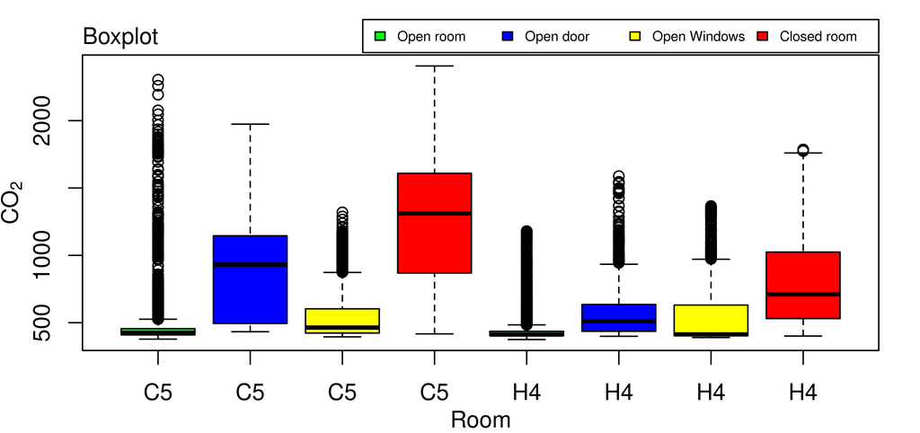

Boxplot das concentrações de CO$_2$ em função da sala e da situação da mesma.

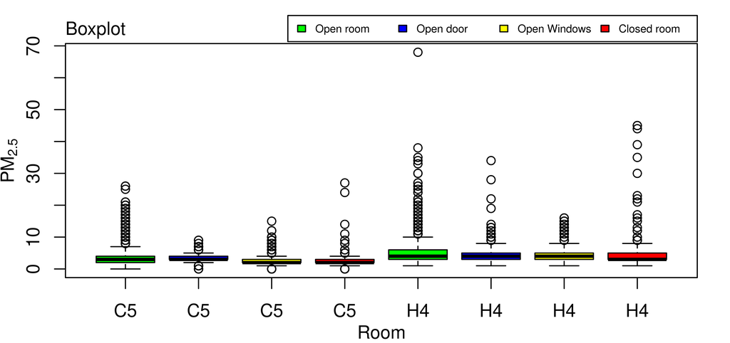

Boxplot das concentrações de PM$_{2.5}$ em função da sala e da situação da mesma.

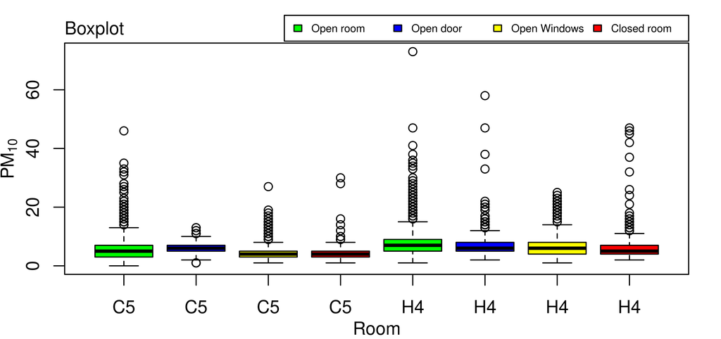

Boxplot das concentrações de PM$_{10}$ em função da sala e da situação da mesma.

Aparentemente, as figuras acima indicam que, no caso do CO$_2$, situações com a sala totalmente aberta parecem fornecer níveis menores do poluente, o que é esperado, tendo em vista que esse poluente pode ser emitido pelos ocupantes da sala, de modo que a sala aberta favorece a dissipação do mesmo. Para esse poluente, a situação da sala aparentemente tem um efeito importante, no sentido de que em situações de porta aberta e sala totalmente fechada as concentrações tendem a ser maiores na sala E5 em comparação com a sala H4. No caso do PM$_{2.5}$ e PM$_{10}$, percebemos a ocorrência de muitas observações discrepantes, o que inclusive dificulta a visualização dos boxplot’s. Desses gráficos, não fica evidente uma diferença provocada pelo local da sala. Entretanto, o papel da situação da sala parece se inverter, quando comparado com o CO$_2$. Aparentemente, nesse caso, a sala totalmente aberta parece fornecer concentrações maiores do que em outras situações, o que pode ser explicado pelo fato de que os ocupantes não constituem fonte emissora de material particulado, sendo a grande maioria proveniente do ambiente externo, de modo que a sala aberta favoreceria ao aumento do efeito dos níveis externos nos níveis internos desses poluentes.

As tabelas abaixo mostram algumas medidas descritivas relativas a esses poluentes computadas em cada sala e em cada situação.

Medidas resumo das concentrações de CO$_{2}$

| LOCAL | SALA | min | 1st quantile | median | mean | std. dev. | 3rd quantile | max |
| --- | --- | --- | --- | --- | --- | --- | --- | --- |
| C5 | OR | 378.00 | 409.00 | 424.00 | 456.00 | 129.00 | 456.00 | 2304.00 |
| C5 | OD | 433.00 | 494.00 | 931.00 | 938.00 | 431.00 | 1146.00 | 1974.00 |
| C5 | OW | 395.00 | 423.00 | 464.00 | 553.00 | 188.00 | 603.00 | 1319.00 |
| C5 | CR | 417.00 | 868.00 | 1311.00 | 1283.00 | 466.00 | 1609.00 | 2406.00 |
| H4 | OR | 375.00 | 404.00 | 412.00 | 442.00 | 93.70 | 436.00 | 1180.00 |
| H4 | OD | 399.00 | 436.00 | 512.00 | 580.00 | 204.00 | 636.00 | 1588.00 |
| H4 | OW | 390.00 | 404.00 | 413.00 | 535.00 | 226.00 | 631.00 | 1366.00 |
| H4 | CR | 401.00 | 530.00 | 711.00 | 835.00 | 385.00 | 1024.00 | 1786.00 |

Medidas resumo das concentrações de PM$_{2.5}$

| LOCAL | SALA | min | 1st quantile | median | mean | std. dev. | 3rd quantile | max |
| --- | --- | --- | --- | --- | --- | --- | --- | --- |
| C5 | OR | 0.00 | 2.00 | 3.00 | 3.14 | 1.96 | 4.00 | 26.00 |
| C5 | OD | 0.00 | 3.00 | 3.00 | 3.61 | 1.47 | 4.00 | 9.00 |
| C5 | OW | 0.00 | 2.00 | 2.00 | 2.64 | 1.39 | 3.00 | 15.00 |
| C5 | CR | 0.00 | 2.00 | 2.00 | 2.58 | 1.38 | 3.00 | 27.00 |
| H4 | OR | 1.00 | 3.00 | 4.00 | 4.65 | 2.28 | 6.00 | 68.00 |
| H4 | OD | 1.00 | 3.00 | 4.00 | 4.21 | 2.23 | 5.00 | 34.00 |
| H4 | OW | 1.00 | 3.00 | 4.00 | 4.10 | 2.17 | 5.00 | 16.00 |
| H4 | CR | 1.00 | 3.00 | 3.00 | 3.99 | 2.94 | 5.00 | 45.00 |

Medidas resumo das concentrações de PM$_{10}$

| LOCAL | SALA | min | 1st quantile | median | mean | std. dev. | 3rd quantile | max |
| --- | --- | --- | --- | --- | --- | --- | --- | --- |
| C5 | OR | 0.00 | 3.00 | 5.00 | 5.25 | 2.90 | 7.00 | 46.00 |
| C5 | OD | 1.00 | 5.00 | 6.00 | 5.97 | 2.28 | 7.00 | 13.00 |
| C5 | OW | 1.00 | 3.00 | 4.00 | 4.44 | 2.13 | 5.00 | 27.00 |
| C5 | CR | 1.00 | 3.00 | 4.00 | 4.35 | 1.93 | 5.00 | 30.00 |
| H4 | OR | 1.00 | 5.00 | 7.00 | 7.28 | 3.28 | 9.00 | 73.00 |
| H4 | OD | 2.00 | 5.00 | 6.00 | 6.70 | 3.61 | 8.00 | 58.00 |
| H4 | OW | 1.00 | 4.00 | 6.00 | 6.42 | 3.39 | 8.00 | 25.00 |
| H4 | CR | 2.00 | 4.00 | 5.00 | 6.15 | 3.63 | 7.00 | 47.00 |

As tabelas acima parecem corroborar com as conclusões tiradas dos boxplot’s apresentados anteriormente.

Além da distribuição dos poluentes em diferentes salas e em situações distintas, é interessante averiguar a dinâmica temporal dos mesmos. As figuras abaixo mostram a evolução dos poluentes e a da ocupação com o passar do tempo.

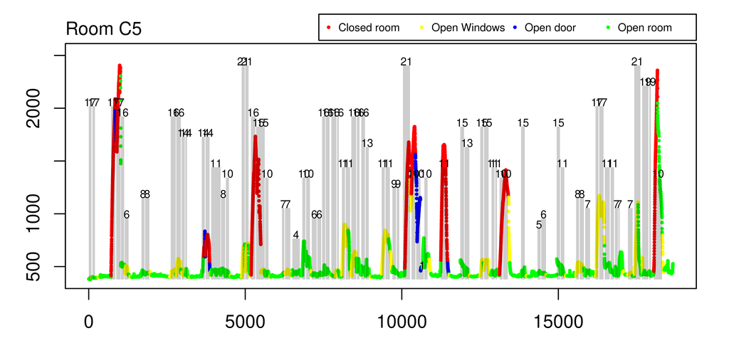

Evolução temporal do CO$_2$ e períodos de ocupação (retângulos cinzas) para a Sala E5, de acordo com a situação da sala: sala totalmente fechada (pontos vermelhos); apenas janela(s) aberta(s) (pontos amarelos); apenas porta(s) aberta(s) (pontos azuis); porta(s) e janelas(s) abertas (pontos verdes). Os números acima dos retângulos cinzas indicam a ocupação da sala no respectivo período.

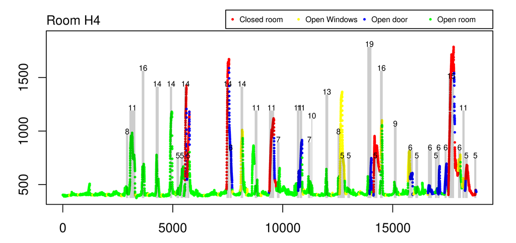

Evolução temporal do CO$_2$ e períodos de ocupação (retângulos cinzas) para a Sala H4, de acordo com a situação da sala: sala totalmente fechada (pontos vermelhos); apenas janela(s) aberta(s) (pontos amarelos); apenas porta(s) aberta(s) (pontos azuis); porta(s) e janelas(s) abertas (pontos verdes). Os números acima dos retângulos cinzas indicam a ocupação da sala no respectivo período.

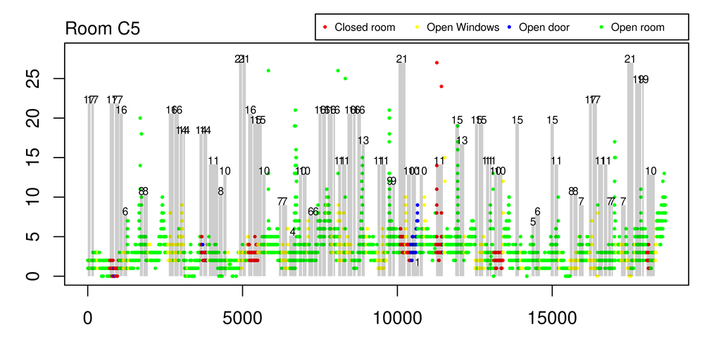

Evolução temporal do PM$_{2.5}$ e períodos de ocupação (retângulos cinzas) para a Sala E5, de acordo com a situação da sala: sala totalmente fechada (pontos vermelhos); apenas janela(s) aberta(s) (pontos amarelos); apenas porta(s) aberta(s) (pontos azuis); porta(s) e janelas(s) abertas (pontos verdes). Os números acima dos retângulos cinzas indicam a ocupação da sala no respectivo período.

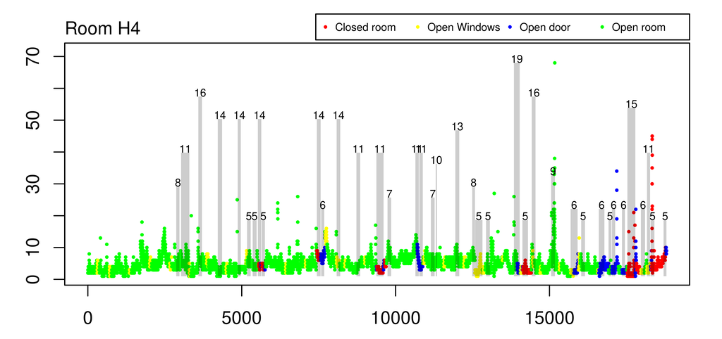

Evolução temporal do PM$_{2.5}$ e períodos de ocupação (retângulos cinzas) para a Sala H4, de acordo com a situação da sala: sala totalmente fechada (pontos vermelhos); apenas janela(s) aberta(s) (pontos amarelos); apenas porta(s) aberta(s) (pontos azuis); porta(s) e janelas(s) abertas (pontos verdes). Os números acima dos retângulos cinzas indicam a ocupação da sala no respectivo período.

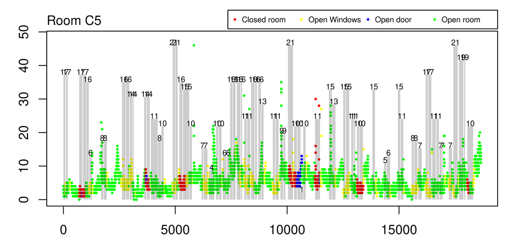

Evolução temporal do PM$_{10}$ e períodos de ocupação (retângulos cinzas) para a Sala E5, de acordo com a situação da sala: sala totalmente fechada (pontos vermelhos); apenas janela(s) aberta(s) (pontos amarelos); apenas porta(s) aberta(s) (pontos azuis); porta(s) e janelas(s) abertas (pontos verdes). Os números acima dos retângulos cinzas indicam a ocupação da sala no respectivo período.

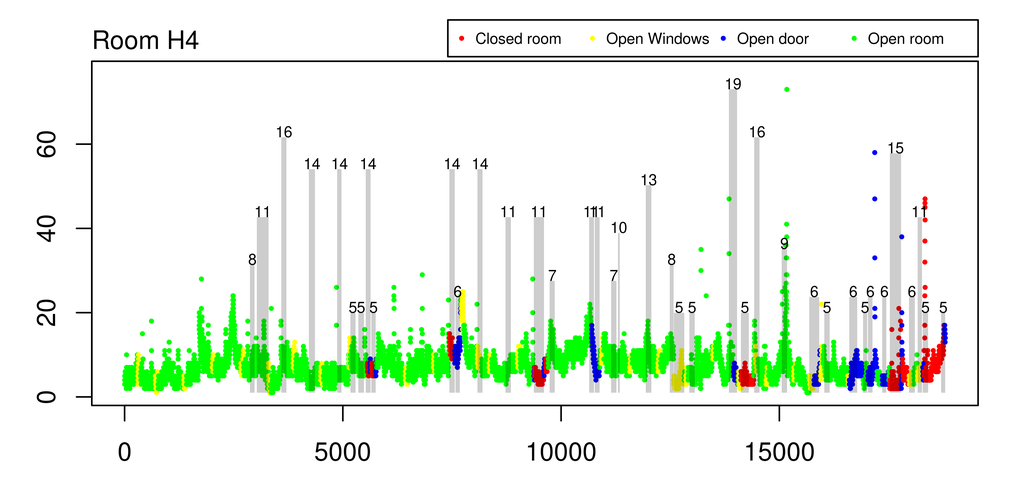

Evolução temporal do PM$_{10}$ e períodos de ocupação (retângulos cinzas) para a Sala H4, de acordo com a situação da sala: sala totalmente fechada (pontos vermelhos); apenas janela(s) aberta(s) (pontos amarelos); apenas porta(s) aberta(s) (pontos azuis); porta(s) e janelas(s) abertas (pontos verdes). Os números acima dos retângulos cinzas indicam a ocupação da sala no respectivo período.

Dos gráficos de evolução acima é possível notar que: (1) para o CO$_2$ é nítido um efeito positivo da ocupação da sala, o mesmo não fica claro para o PM$_{2.5}$ e o PM$_{10}$; (2) para o CO$_2$, fica nítida a diferença de comportamento entre as Salas E5 e H4, por exemplo, na Sala E5, a sala estar totalmente fechada provoca um incremento muito maior do CO$_2$ reportado, enquanto que na Sala H4 essa diferença parece ser muito menos dramática; (3) para o CO$_2$ é notável que o aumento da ocupação da sala provoca um aumento progressivo (não instantâneo) no CO$_2$; (4) a sala H4 aparentemente apresentou valores discrepantes de PM$_{2.5}$ e de PM$_{10}$. É importante avaliar se se tratam de falhas de equipamento; (5) se não se tratar de falha o que é descrito no Item (4), é notável a diferença de comportamento do PM$_{2.5}$ e do PM$_{10}$ entre as Salas E5 e H4, a saber, os valores discrepantes ocorreram na Sala H4, o que pode indicar a influência de algum fator responsável por causar essas altas concentrações.

Para evitar a necessidade de se considerar um modelo extremamente complexo para explicar o comportamento discutido no Item (3), foi realizada a agregação dos dados como se segue. A cada hora, e a cada mudança de abertura de janelas e/ou portas ou de ocupação, as demais variáveis (concentrações internas e externas de CO$_2$, PM$_{2.5}$ e PM$_{10}$) foram agregadas por meio da média aritmética.

A metodologia estatística empregada para a análise dos dados é brevemente introduzida a seguir.